# WEEK 13 Part2 IP R PROGRAMMING

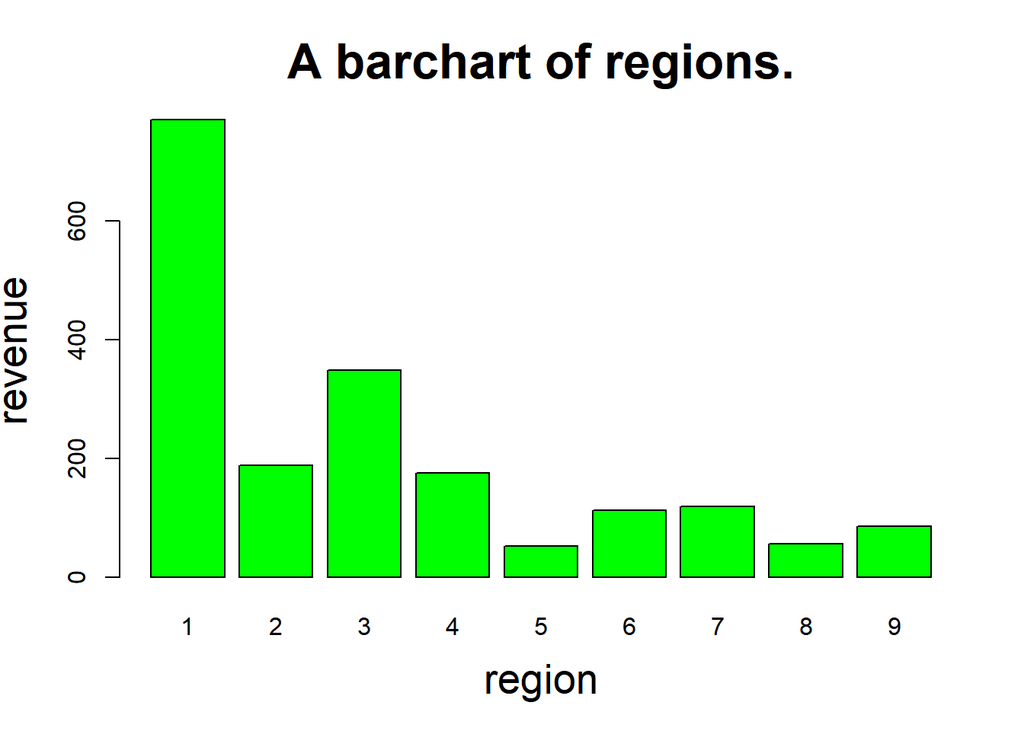

```r
#Bar chart to show frequency distribution of regions
options(repr.plot.width = 10, repr.plot.height = 10)
barplot(c(region1.freq), main="A barchart of regions.",
        xlab="region",
        ylab="revenue",
        cex.main=2, cex.lab=1.7,cex.sub=1.2,
        col=c("green"))
```

```r
#comparison between traffic type and revenue brought in
#frequency table of traffic type
traffic1.freq <- table(revenue$TrafficType)
sort(traffic1.freq, decreasing = TRUE)[1:5]
```

```
##
##   2   1   3   4   8
## 847 262 180 165  95
```

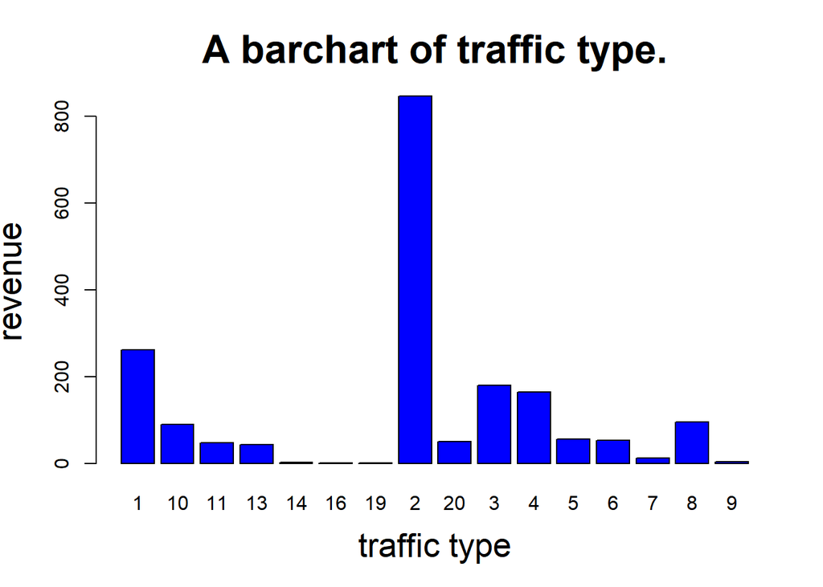

```r
#Bar chart to show frequency distribution of traffic type
options(repr.plot.width = 10, repr.plot.height = 10)
barplot(c(traffic1.freq), main="A barchart of traffic type.",
        xlab="traffic type",
        ylab="revenue",
        cex.main=2, cex.lab=1.7,cex.sub=1.2,
        col=c("blue"))
```

```r
#comparison between visitor type and revenue brought in
#frequency table of visitor type
visitor1.freq <- table(revenue$VisitorType)
sort(visitor1.freq, decreasing = TRUE)[1:5]
```

```
##
## Returning_Visitor       New_Visitor             Other              <NA>
##              1470               422                16
##              <NA>
##
```

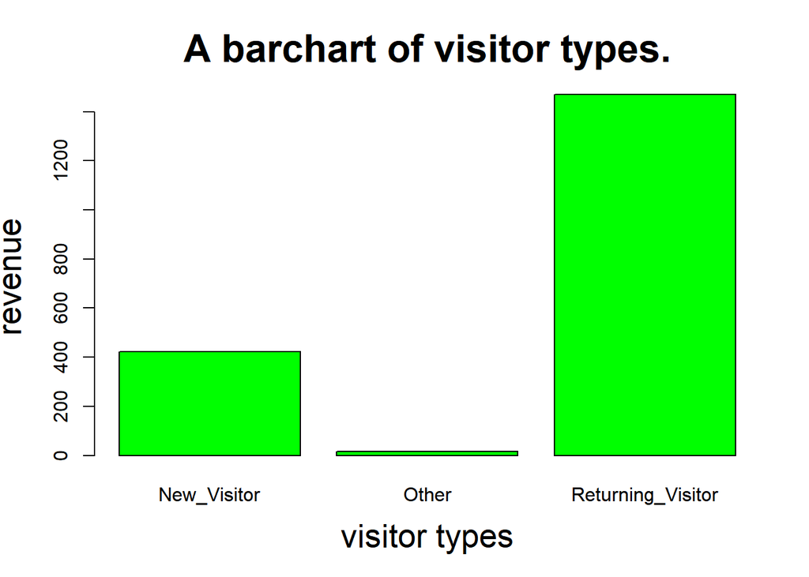

```r
#Bar chart to show frequency distribution of visitor type
options(repr.plot.width = 10, repr.plot.height = 10)
barplot(c(visitor1.freq), main="A barchart of visitor types.",
        xlab="visitor types",
        ylab="revenue",
        cex.main=2, cex.lab=1.7,cex.sub=1.2,
        col=c("green"))
```

```r
#comparison between weekend and revenue brought in
#frequency table of weekend
weekend1.freq <- table(revenue$Weekend)
sort(weekend1.freq, decreasing = TRUE)[1:5]
```

```
##
## FALSE  TRUE  <NA>  <NA>  <NA>
##  1409   499
```

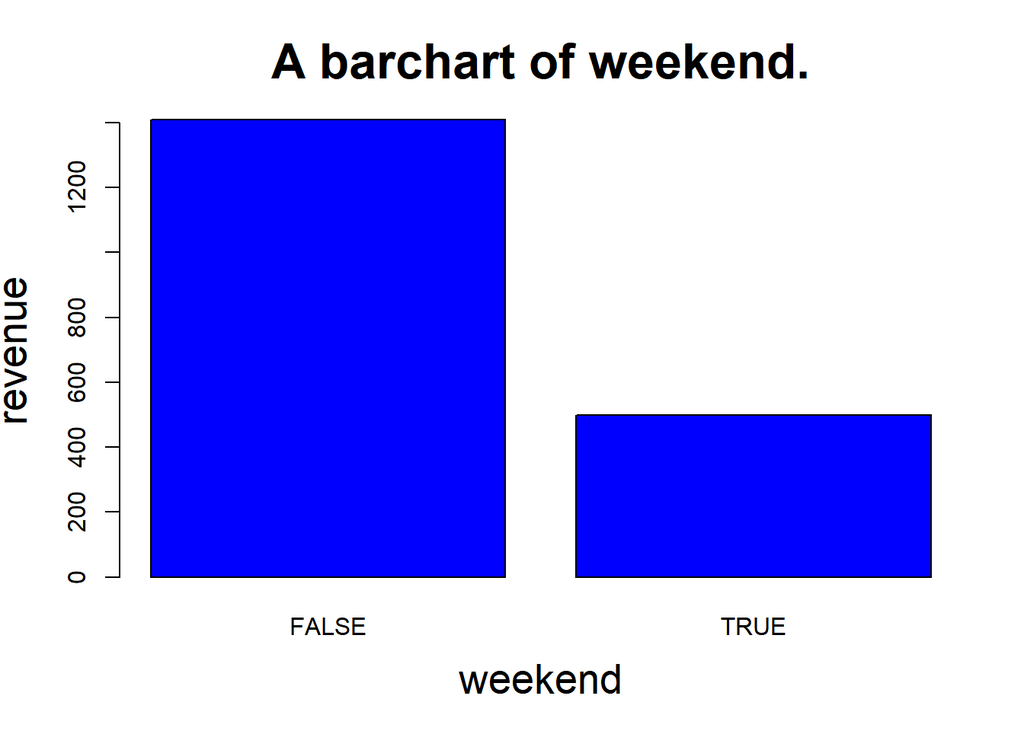

```r
#Bar chart to show frequency distribution of weekend
options(repr.plot.width = 10, repr.plot.height = 10)
barplot(c(weekend1.freq), main="A barchart of weekend.",
        xlab="weekend",
        ylab="revenue",
        cex.main=2, cex.lab=1.7,cex.sub=1.2,
        col=c("blue"))
```

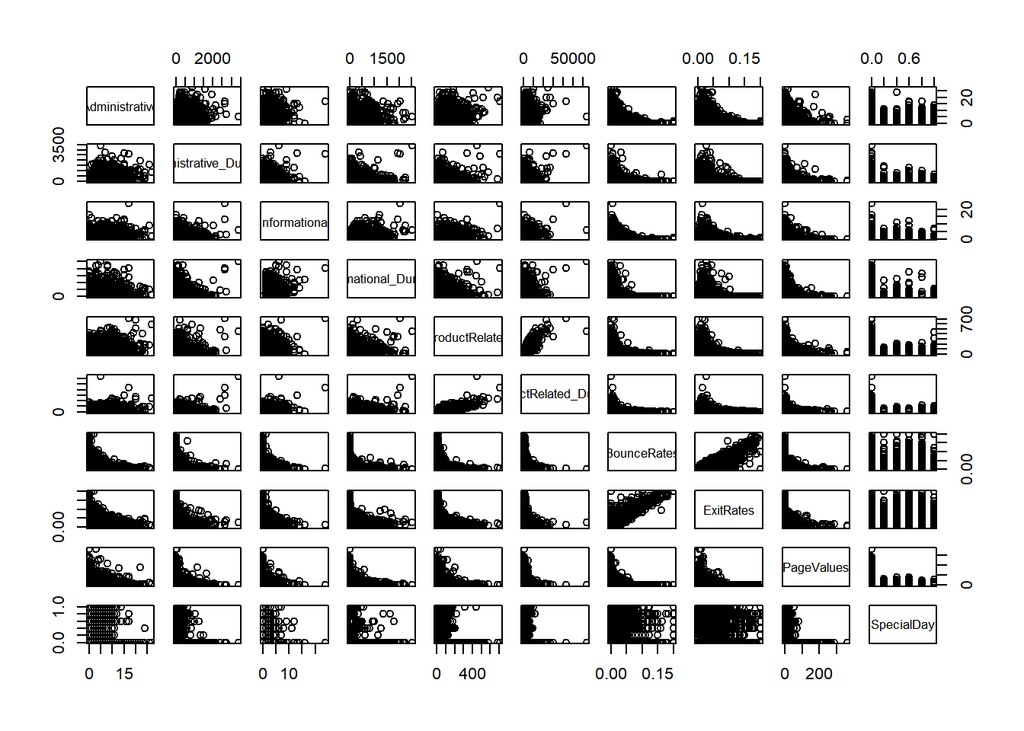

```r
#Pair plots
pairs(ec[, 1:10])
```

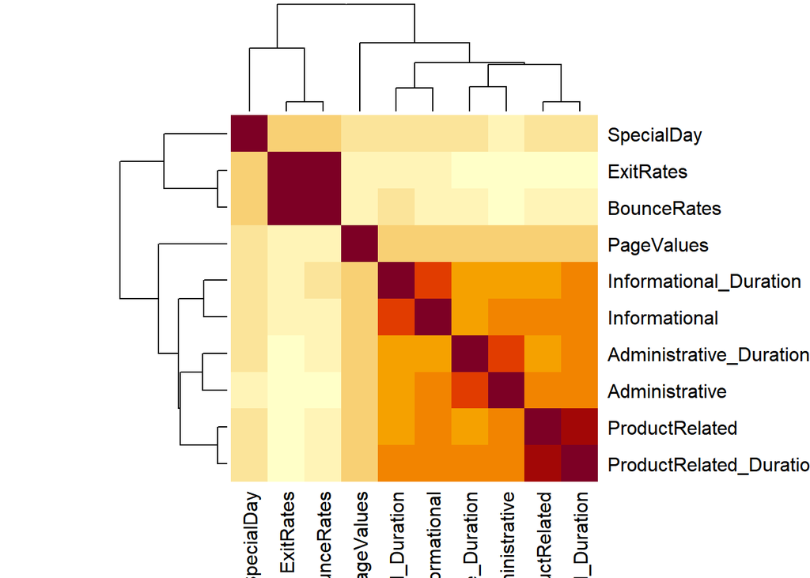

```r
#Plotting a heat map using the correlation matrix
heatmap(x=cor, symm=TRUE)
```

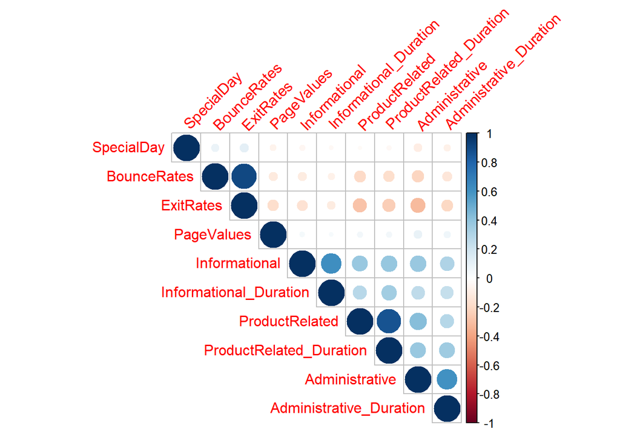

```r
#Plotting a correlogram
library('corrplot')
corrplot(cor, type='upper', order='hclust', tl.color='black', tl.srt=45)
```

### Observations from Bivariate and multivariate analysis

- Most revenue was made in the month of May. This would be because it also had the most web page visits.
- Operating system type 2 brought in more revenue.
- Users of browser type 2 also brought in more revenue.
- A great portion of revenue was gotten from region 1
- The traffic type that brought in most revenue was type 2
- Returning visitors also brought in more revenue as compared to the new and other visitors.
- A larger amount of revenue was made during the weekdays.
- Bounce rates and exit rates are highly correlated
- The number of product related websites visited is highly correlated to the product related duration spent.

#7. Implementing the Solution